# homework4

b06208016楊鎧綾

October 5, 2018

# 8.18

## a

```r
samplespace=c("RR","RL","LR","LL")
```

## b

```r
probability=c((7*6)/(10*9),(7*3)/(10*9),(3*7)/(10*9),(3*2)/(10*9))
data.frame(samplespace,probability)
```

```
##   samplespace probability
## 1          RR  0.46666667
## 2          RL  0.23333333
## 3          LR  0.23333333
## 4          LL  0.06666667
```

## c

```r
X=c(0,1,2)
prob=c((7*6)/(10*9),(7*3)/(10*9)+(3*7)/(10*9),(3*2)/(10*9))
d=data.frame(simpleevent=X,probability=prob)
d
```

```
##   simpleevent probability
## 1           0  0.46666667
## 2           1  0.46666667
## 3           2  0.06666667
```

## d

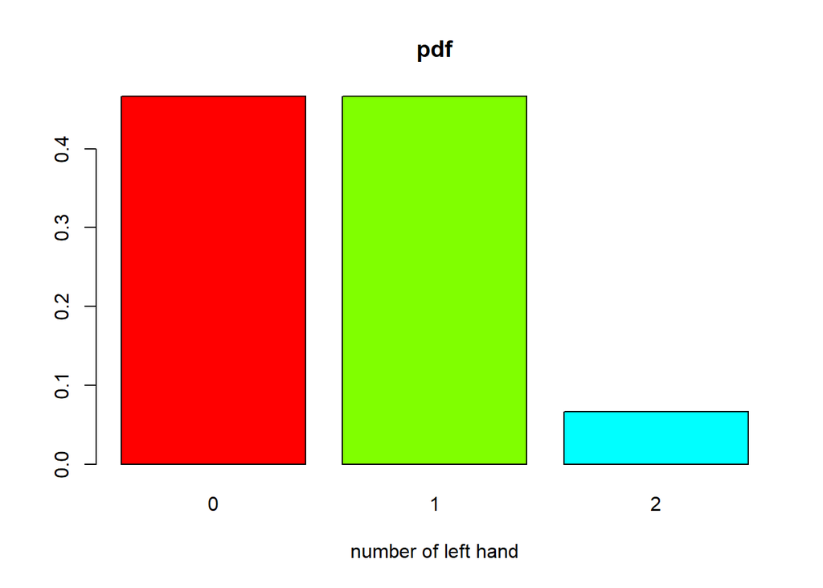

```r
barplot(d$probability,names.arg = d$simpleevent, main="pdf", col=rainbow(4),xlab="number of left hand")
```

# 8.40

## a

```r
0.2*20+0.8*15
```

```
## [1] 16
```

## b

a小題的期待值並不代表真正的通勤時間，期待值有一種預定的平均值的概念，預計通勤了很多次以後，把每次平均起來大約是16分鐘，但實際上的通勤時間在題目的假設中是15分鐘或20分鐘，不會有任一次是16分鐘。

# 8.50

X=human wins ##a P(X=5)

```r
dbinom(5,10,0.5)
```

```
## [1] 0.2460938
```

## b

P(X=3),computer wins 7 times means human wins 3 times

```r
dbinom(3,10,0.5)
```

```
## [1] 0.1171875
```

## c

P(X>=7)

```r
1-pbinom(6,10,0.5)
```

```
## [1] 0.171875
```

# 8.72

mean=500,sd=100

## a

P(X<=500)

```r
pnorm(500,500,100)
```

```
## [1] 0.5
```

## b

P(X<=650)

```r
pnorm(650,500,100)
```

```
## [1] 0.9331928
```

## c

P(X>=700)

```r
1-pnorm(699,500,100)
```

```
## [1] 0.02329547
```

## d

P(500<=X<=700)=P(X<=700)-P(X<500)

```r
pnorm(700,500,100)-pnorm(499,500,100)
```

```
## [1] 0.4812392
```

# 8.82

## a

```r
n=100
p=0.5
mean=n*p
mean
```

```
## [1] 50
```

```r
sd=sqrt(n*p*(1-p))
sd
```

```
## [1] 5
```

## b

P(N>=60)

```r
1-pnorm(59,mean,sd)
```

```
## [1] 0.03593032
```

## c

```r
1-pnorm(59.5,mean,sd)
```

```
## [1] 0.02871656
```

## d

P(N>=60)

```r
1-pbinom(59,n,p)
```

```
## [1] 0.02844397
```

## e

以binomial來計算的機率(也就是d小題)會最接近真正的分布。  
然後最不準確的是以59來計算的normal approximation。也就是b小題，他距離二項分布的數值最遠，雖然試驗次數很多的時候，二向分布會趨於常態分布，但是畢竟還是有差別，而c小題為經過調整項的，因此b與實際狀況相差最遠。

# 8.90

## a

because the heights of adult males is a normal distribution,the minus of two normal distribution is also a normal distribution  
so X-Y is a normal distribution

## b

```r
70-70
```

```
## [1] 0
```

## c

```r
sdd=sqrt((2.8^2)+(2.8^2))
sdd
```

```
## [1] 3.959798
```

## d

```r
dd=1-pnorm(3,0,sdd)
dd
```

```
## [1] 0.2243409
```

## e

因為為常態分布所以左右對稱，小於-3與大於3的機率相等

```r
2*dd
```

```
## [1] 0.4486819
```

# r function

## 1

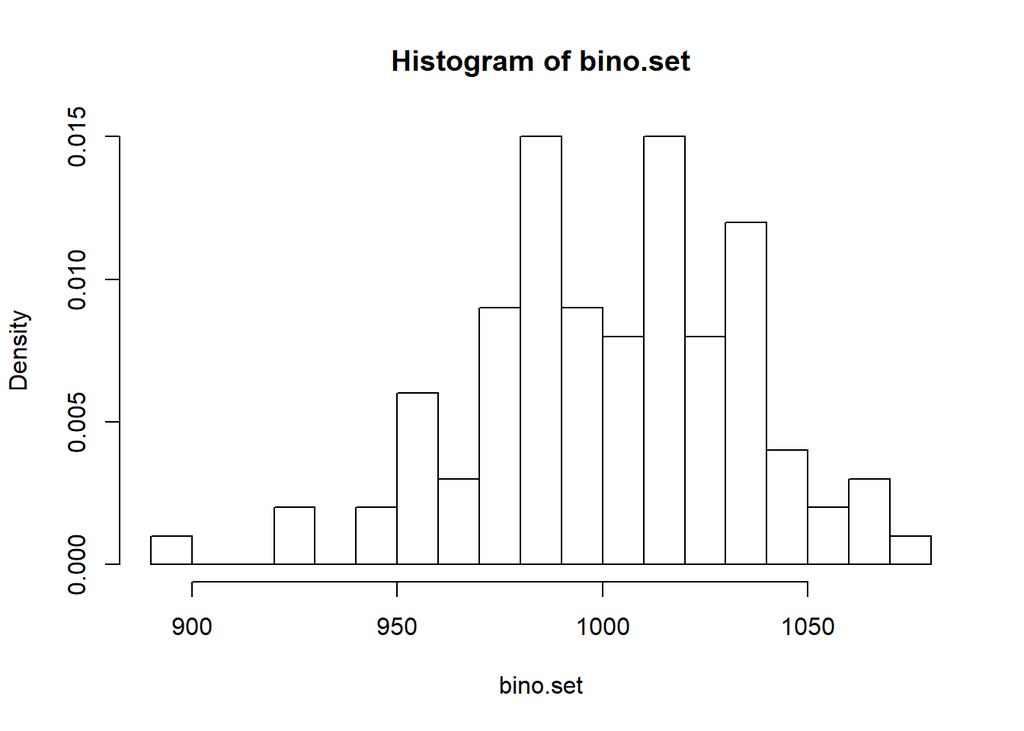

```r
#Generate one binomial random variable
Bino.event = function(n, p) {
  simp.event = c()
  pp = 100*p

  for (i in 1:n) {
    samp = sample(1:100, 1, replace = T)

    # an event with probability p
    if (samp <= pp) {
      event = 1
    } else {
      event = 0
    }

    simp.event[i] = event
  }

  x = sum(simp.event)

  return(x)
}

# Generate a set of binomial random variable
bino.set = c()

for (i in 1:100) {
  bino.set[i] = Bino.event(n = 100000, p = 0.01)
}

hist(bino.set, prob = T, breaks = 20)
```

## 2

```r
pb=pbinom(1050,100000,0.01)
1-(pb^4)
```

```
## [1] 0.2029376
```

## 3

延續第一小題

```r
max(bino.set)
```

```
## [1] 1073
```